# Lab 8

Joshua Klugman

# Lab 8 overview

The data in the file `wordsum v2.sav` is a vocabulary test administered to people from different regions of the United States, with scores ranging from 0 to 10. We have a 2×4 design, with our two factors being a city resident (versus not being a city resident; this is variable `sized`) and region (Midwest, Northeast, South, and West; this is variable `regions`). The outcome is the vocabulary score (variable `ws` which is a count variable ranging from 0 correct words to 10 correct words).

# Problem 1

Load packages and Wilcox functions.

```r
# packages
library(afex)
library(car)
library(emmeans)
library(haven)
source("https://osf.io/download/98b7r/")
```

# Problem 2

Read in the `wordsum v2.sav` datafile.

```r
ws <- read_sav("wordsum v2.sav")
```

# Problem 3

Inspect labels, create factor versions, and verify construction.

```r
attr(ws$sized, "labels")
```

```
## Non-City     City
##        0        1
```

```r
attr(ws$regions, "labels")
```

```
##   Midwest Northeast     South      West
##         1         2         3         4
```

```r
ws$sized_f <- factor(ws$sized,
                     levels = c(0, 1),
                     labels = c("Non-City", "City"))

ws$regions_f <- factor(ws$regions,
                       levels = c(1, 2, 3, 4),
                       labels = c("Midwest", "Northeast", "South", "West"))

# confirm factor construction

table(ws$sized, ws$sized_f, exclude = NULL)
```

```
##
##     Non-City City
##   0      160    0
##   1        0  160
```

```r
table(ws$regions, ws$regions_f, exclude = NULL)
```

```
##
##     Midwest Northeast South West
##   1      80         0     0    0
##   2       0        80     0    0
##   3       0         0    80    0
##   4       0         0     0   80
```

# Problem 4

Create a superfactor and cross-tabulate with city status and region.

```r
ws <- group_by(ws, sized_f, regions_f)
ws <- mutate(ws, regionsize_new = cur_group_id())
ws <- ungroup(ws)

# add labels for the superfactor
ws$regionsize_new_f <- factor(ws$regionsize_new,
                              levels = 1:8,
                              labels = c("Midwest Non-City", "Northeast Non-City",
                                         "South Non-City", "West Non-City",
                                         "Midwest City", "Northeast City",
                                         "South City", "West City"))

# cross-tabs

table(ws$regionsize_new_f, ws$sized_f, exclude = NULL)
```

```
##
##                      Non-City City
##   Midwest Non-City         40    0
##   Northeast Non-City       40    0
##   South Non-City           40    0
##   West Non-City            40    0
##   Midwest City              0   40
##   Northeast City            0   40
##   South City                0   40
##   West City                 0   40
```

```r
table(ws$regionsize_new_f, ws$regions_f, exclude = NULL)
```

```
##
##                      Midwest Northeast South West
##   Midwest Non-City        40         0     0    0
##   Northeast Non-City       0        40     0    0
##   South Non-City           0         0    40    0
##   West Non-City            0         0     0   40
##   Midwest City            40         0     0    0
##   Northeast City           0        40     0    0
##   South City               0         0    40    0
##   West City                0         0     0   40
```

# Problem 5

Histograms by city status and region.

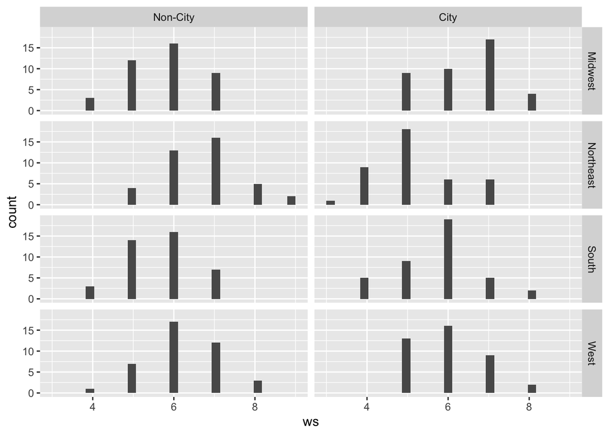

Vocabulary scores by region and city status

```r
ggplot(data = ws, aes(x = ws)) +
  geom_histogram() +
  facet_grid(regions_f ~ sized_f)
```

# Problem 6

Skewness statistics and Shapiro-Wilk tests for each cell.

```r
tapply(ws$ws, ws$regionsize_new_f, pastecs::stat.desc, norm = TRUE)
```

```
## $`Midwest Non-City`
##       nbr.val      nbr.null        nbr.na           min           max
##  4.000000e+01  0.000000e+00  0.000000e+00  4.000000e+00  7.000000e+00
##         range           sum        median          mean       SE.mean
##  3.000000e+00  2.310000e+02  6.000000e+00  5.775000e+00  1.409105e-01
##  CI.mean.0.95           var       std.dev      coef.var      skewness
##  2.850184e-01  7.942308e-01  8.911963e-01  1.543197e-01 -1.990720e-01
##      skew.2SE      kurtosis      kurt.2SE    normtest.W    normtest.p
## -2.662933e-01 -8.433740e-01 -5.756031e-01  8.726088e-01  3.346659e-04
##
## $`Northeast Non-City`
##       nbr.val      nbr.null        nbr.na           min           max
##  40.000000000   0.000000000   0.000000000   5.000000000   9.000000000
##         range           sum        median          mean       SE.mean
##   4.000000000 268.000000000   7.000000000   6.700000000   0.156892908
##  CI.mean.0.95           var       std.dev      coef.var      skewness
##   0.317345861   0.984615385   0.992277877   0.148101176   0.297846885
##      skew.2SE      kurtosis      kurt.2SE    normtest.W    normtest.p
##   0.398421804  -0.243125610  -0.165933332   0.902415068   0.002249134
##
## $`South Non-City`
##       nbr.val      nbr.null        nbr.na           min           max
##  4.000000e+01  0.000000e+00  0.000000e+00  4.000000e+00  7.000000e+00
##         range           sum        median          mean       SE.mean
##  3.000000e+00  2.270000e+02  6.000000e+00  5.675000e+00  1.358143e-01
##  CI.mean.0.95           var       std.dev      coef.var      skewness
##  2.747103e-01  7.378205e-01  8.589648e-01  1.513594e-01 -6.198109e-02
##      skew.2SE      kurtosis      kurt.2SE    normtest.W    normtest.p
## -8.291044e-02 -7.830269e-01 -5.344162e-01  8.733777e-01  3.506108e-04
##
## $`West Non-City`
##       nbr.val      nbr.null        nbr.na           min           max
##  40.000000000   0.000000000   0.000000000   4.000000000   8.000000000
##         range           sum        median          mean       SE.mean
##   4.000000000 249.000000000   6.000000000   6.225000000   0.145388516
##  CI.mean.0.95           var       std.dev      coef.var      skewness
##   0.294076031   0.845512821   0.919517711   0.147713688  -0.055107052
##      skew.2SE      kurtosis      kurt.2SE    normtest.W    normtest.p
##  -0.073715228  -0.397379239  -0.271211499   0.901290712   0.002084817
##
```

[output cut: 24 more lines]

```
## 230.00000000   6.00000000   5.75000000   0.15912421   0.32185909   1.01282051
##      std.dev     coef.var     skewness     skew.2SE     kurtosis     kurt.2SE
##   1.00638984   0.17502432   0.05518535   0.07381996  -0.23921197  -0.16326227
##   normtest.W   normtest.p
##   0.89384641   0.00127206
##
## $`West City`
##       nbr.val      nbr.null        nbr.na           min           max
##  4.000000e+01  0.000000e+00  0.000000e+00  5.000000e+00  8.000000e+00
##         range           sum        median          mean       SE.mean
##  3.000000e+00  2.400000e+02  6.000000e+00  6.000000e+00  1.386750e-01
##  CI.mean.0.95           var       std.dev      coef.var      skewness
##  2.804968e-01  7.692308e-01  8.770580e-01  1.461763e-01  4.446684e-01
##      skew.2SE      kurtosis      kurt.2SE    normtest.W    normtest.p
##  5.948210e-01 -7.185000e-01 -4.903766e-01  8.499722e-01  8.982408e-05
```

# Problem 7

Levene’s test for homogeneity of variance.

```r
car::leveneTest(ws ~ regionsize_new_f, data = ws, center = mean)
```

|  | Df | F value | Pr(>F) |
| --- | --- | --- | --- |
| group | 7 | 0.4183524 | 0.8906697 |
|  | 312 | NA | NA |

# Problem 8

Use MAD-Median rule to detect outliers.

```r
o <- tapply(ws$ws, ws$regionsize_new_f, outpro)
o
```

```
## $`Midwest Non-City`
## $`Midwest Non-City`$n
## [1] 40
##
## $`Midwest Non-City`$n.out
## [1] 0
##
## $`Midwest Non-City`$out.id
## integer(0)
##
## $`Midwest Non-City`$keep
##  [1]  1  2  3  4  5  6  7  8  9 10 11 12 13 14 15 16 17 18 19 20 21 22 23 24 25
## [26] 26 27 28 29 30 31 32 33 34 35 36 37 38 39 40
##
##
## $`Northeast Non-City`
## $`Northeast Non-City`$n
## [1] 40
##
## $`Northeast Non-City`$n.out
## [1] 0
##
## $`Northeast Non-City`$out.id
## integer(0)
##
## $`Northeast Non-City`$keep
##  [1]  1  2  3  4  5  6  7  8  9 10 11 12 13 14 15 16 17 18 19 20 21 22 23 24 25
## [26] 26 27 28 29 30 31 32 33 34 35 36 37 38 39 40
##
##
## $`South Non-City`
## $`South Non-City`$n
## [1] 40
##
## $`South Non-City`$n.out
## [1] 0
##
## $`South Non-City`$out.id
## integer(0)
##
```

[output cut: 63 more lines]

```
##
##
## $`West City`
## $`West City`$n
## [1] 40
##
## $`West City`$n.out
## [1] 0
##
## $`West City`$out.id
## integer(0)
##
## $`West City`$keep
##  [1]  1  2  3  4  5  6  7  8  9 10 11 12 13 14 15 16 17 18 19 20 21 22 23 24 25
## [26] 26 27 28 29 30 31 32 33 34 35 36 37 38 39 40
```

```r
# If outliers appear in any group, run this for each group with outliers:
# ws$ws[ws$regionsize_new_f=="GROUP NAME"][o[["GROUP NAME"]]$out.id]
```

# Problem 9

Diagnostics write-up (3 sentences maximum).

Based on the histograms and skewness statistics, the distributions appear only modestly skewed across cells. Shapiro-Wilk tests indicate statistically significant departures from normality in each cell (all p-values < .01). Levene’s test suggests homogeneity of variances across the eight cells (p = .8907), and the MAD-Median rule indicates no outliers in any cell.

# Problem 10

Create an ID variable.

```r
ws$id <- rownames(ws)
```

# Problem 11

Cell and marginal means.

```r
ws_anova <- aov_car(ws ~ sized_f * regions_f + Error(id), data = ws)

# cell means
emmeans(ws_anova, ~ sized_f * regions_f)
```

```
##  sized_f  regions_f emmean    SE  df lower.CL upper.CL
##  Non-City Midwest     5.78 0.149 312     5.48     6.07
##  City     Midwest     6.40 0.149 312     6.11     6.69
##  Non-City Northeast   6.70 0.149 312     6.41     6.99
##  City     Northeast   5.17 0.149 312     4.88     5.47
##  Non-City South       5.67 0.149 312     5.38     5.97
##  City     South       5.75 0.149 312     5.46     6.04
##  Non-City West        6.22 0.149 312     5.93     6.52
##  City     West        6.00 0.149 312     5.71     6.29
##
## Confidence level used: 0.95
```

```r
# marginal means
emmeans(ws_anova, ~ sized_f)
```

```
##  sized_f  emmean     SE  df lower.CL upper.CL
##  Non-City   6.09 0.0746 312     5.95     6.24
##  City       5.83 0.0746 312     5.68     5.98
##
## Results are averaged over the levels of: regions_f
## Confidence level used: 0.95
```

```r
emmeans(ws_anova, ~ regions_f)
```

```
##  regions_f emmean    SE  df lower.CL upper.CL
##  Midwest     6.09 0.106 312     5.88     6.30
##  Northeast   5.94 0.106 312     5.73     6.15
##  South       5.71 0.106 312     5.50     5.92
##  West        6.11 0.106 312     5.90     6.32
##
## Results are averaged over the levels of: sized_f
## Confidence level used: 0.95
```

# Problem 12

Excel table of cell means.

Create a 4x2 table in Excel with rows as `regions_f` and columns as `sized_f`. Use the cell means above, round to two decimals, and format with a clear title and minimal borders.

# Problem 13

Interpretability of main effects.

The interaction between city status and region is significant, so the main effects are not safe to interpret. The city vs. non-city differences are not consistent across regions, and the rank order of regions changes across city status.

# Problem 14

Two-way ANOVA output.

```r
summary(ws_anova)
```

|  | num Df | den Df | MSE | F | ges | Pr(>F) |
| --- | --- | --- | --- | --- | --- | --- |
| sized_f | 1 | 312 | 0.8910256 | 6.186691 | 0.01944359 | 1.339365e-02 |
| regions_f | 3 | 312 | 0.8910256 | 3.030216 | 0.02831178 | 2.962464e-02 |
| sized_f:regions_f | 3 | 312 | 0.8910256 | 18.681655 | 0.15227749 | 3.601321e-11 |

```r
ws_anova$Anova
```

|  | Sum Sq | Df | F value | Pr(>F) |
| --- | --- | --- | --- | --- |
| (Intercept) | 11376.4500 | 1 | 12767.814388 | 3.614045e-255 |
| sized_f | 5.5125 | 1 | 6.186691 | 1.339365e-02 |
| regions_f | 8.1000 | 3 | 3.030216 | 2.962464e-02 |
| sized_f:regions_f | 49.9375 | 3 | 18.681655 | 3.601321e-11 |
| Residuals | 278.0000 | 312 | NA | NA |

# Problem 15

Calculate partial omega squared for each effect.

```r
an <- as.data.frame(ws_anova$Anova)
ss <- an$`Sum Sq`
df <- an$Df
names(ss) <- row.names(an)
names(df) <- row.names(an)

ss_error <- ss["Residuals"]
df_error <- df["Residuals"]
mse <- ss_error / df_error

effects <- setdiff(row.names(an), c("(Intercept)", "Residuals"))
ss_effect <- ss[effects]
df_effect <- df[effects]

omega_p <- (ss_effect - df_effect * mse) / (ss_effect + ss_error + mse)

omega_table <- data.frame(
  effect = effects,
  df = df_effect,
  SS = ss_effect,
  SS_error = ss_error,
  MSE = mse,
  omega_p = omega_p
)
omega_table
```

|  | effect | df | SS | SS_error | MSE | omega_p |
| --- | --- | --- | --- | --- | --- | --- |
| sized_f | sized_f | 1 | 5.5125 | 278 | 0.8910256 | 0.01624971 |
| regions_f | regions_f | 3 | 8.1000 | 278 | 0.8910256 | 0.01890973 |
| sized_f:regions_f | sized_f:regions_f | 3 | 49.9375 | 278 | 0.8910256 | 0.14373578 |

# Problem 16

Write up the omnibus results (journal style).

A two-way ANOVA showed a significant main effect of city status, F(1, 312) = 6.19, p = .013, ω²p = 0.016, and a significant main effect of region, F(3, 312) = 3.03, p = .030, ω²p = 0.019. There was also a significant city status × region interaction, F(3, 312) = 18.68, p < .001, ω²p = 0.144. Because the interaction is significant, interpretation should focus on the cell means rather than the marginal main effects.

# Problem 17

Upload the document to Canvas and verify the submission.